# EasyVisa_Full_Code_Notebook_final

#### Is the prevailing wage consistent across all regions of the US?

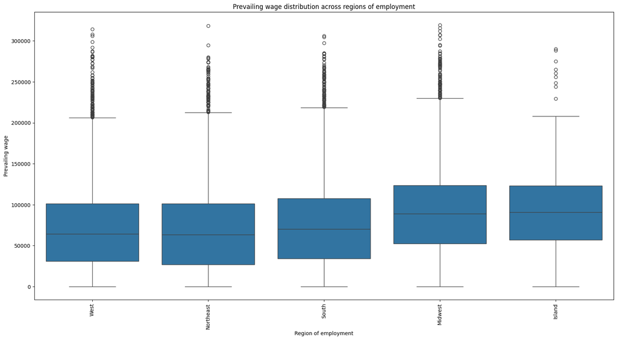

```python
plt.figure(figsize=(20, 10))
sns.boxplot(x='region_of_employment', y='prevailing_wage', data=df)
plt.xticks(rotation=90)
plt.ylabel('Prevailing wage')
plt.xlabel('Region of employment')
plt.title('Prevailing wage distribution across regions of employment')
plt.show()
```

Observations on Prevailing Wage Across Regions:

The prevailing wage varies considerably across the different regions of employment.

The 'Midwest' and 'Island' regions generally show higher median prevailing wages compared to the 'West', 'Northeast', and 'South'.

All regions exhibit a wide distribution of wages, indicated by the height of their boxes and the extent of their whiskers.

Furthermore, all regions display numerous outliers at the higher end of the wage spectrum, suggesting that while the typical wage might vary, there are consistently high-paying positions across all employment regions.

#### Does visa status vary with changes in the prevailing wage set to protect both local talent and foreign workers?

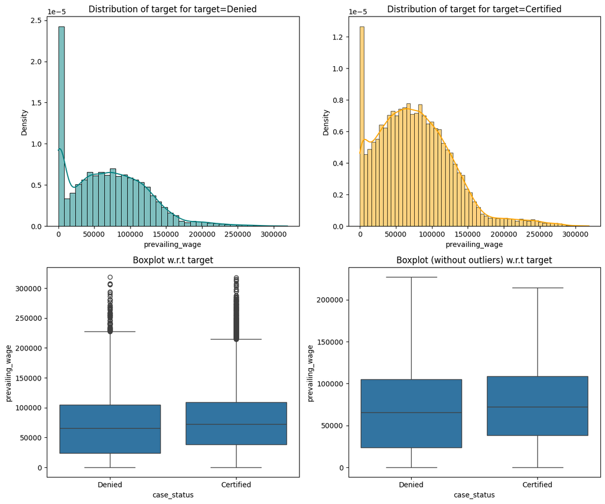

```python
distribution_plot_wrt_target(df, 'prevailing_wage', 'case_status')
```

Observations on Prevailing Wage and Visa Status:

The distribution of prevailing wages for certified and denied cases shows some overlap, but certified cases tend to have a higher median prevailing wage compared to denied cases.

This suggests that a higher prevailing wage might be associated with a greater chance of visa certification, aligning with the INA's goal of ensuring foreign workers are not underpaid.